# assignment 3

Alireza

2023-11-21

**1-** First we read the data. Then, we shuffle it.

```r
path <- "/Users/alireza/Desktop/DTI/1- Fall 23//Fundamentals of Applied Data Science/assignment 3/eBayAuctions (2).csv"
data <- read.csv(path)
set.seed(420)
shuffle_index <- sample(1:nrow(data))
head(shuffle_index)
```

```
## [1]  773  101 1194  462  376   73
```

```r
data <- data[shuffle_index, ]
head(data)
```

```
##                  Category currency sellerRating Duration endDay ClosePrice
## 773          Toys/Hobbies       US         3385        7    Sat       4.95
## 101      Music/Movie/Game       US         3249        5    Mon       6.15
## 1194 Clothing/Accessories      EUR         1166        7    Tue      18.43
## 462           Home/Garden      EUR         1402        7    Fri       3.07
## 376          Toys/Hobbies      EUR          300       10    Wed       2.45
## 73       Music/Movie/Game       US         3249        5    Mon       3.75
##      OpenPrice Competitive.
## 773       4.95            0
## 101       0.01            1
## 1194      6.14            0
## 462       3.07            0
## 376       2.45            0
## 73        0.01            1
```

In this section, we convert the duration variable to categorical variable.

```r
library(dplyr)
clean_data <- data %>% mutate(Duration = factor(Duration, levels = c(3, 5, 7, 10), labels = c("very short", "short", "medium", "long")))
str(clean_data)
```

```
## 'data.frame':    1972 obs. of  8 variables:
##  $ Category    : chr  "Toys/Hobbies" "Music/Movie/Game" "Clothing/Accessories" "Home/Garden" ...
##  $ currency    : chr  "US" "US" "EUR" "EUR" ...
##  $ sellerRating: int  3385 3249 1166 1402 300 3249 411 1375 1364 2695 ...
##  $ Duration    : Factor w/ 4 levels "very short","short",..: 3 2 3 3 4 2 1 2 3 3 ...
##  $ endDay      : chr  "Sat" "Mon" "Tue" "Fri" ...
##  $ ClosePrice  : num  4.95 6.15 18.43 3.07 2.45 ...
##  $ OpenPrice   : num  4.95 0.01 6.14 3.07 2.45 0.01 0.99 6.99 132 2 ...
##  $ Competitive.: int  0 1 0 0 0 1 1 0 1 0 ...
```

```r
head(clean_data)
```

```
##                  Category currency sellerRating Duration endDay ClosePrice
## 773          Toys/Hobbies       US         3385   medium    Sat       4.95
## 101      Music/Movie/Game       US         3249    short    Mon       6.15
## 1194 Clothing/Accessories      EUR         1166   medium    Tue      18.43
## 462           Home/Garden      EUR         1402   medium    Fri       3.07
## 376          Toys/Hobbies      EUR          300     long    Wed       2.45
## 73       Music/Movie/Game       US         3249    short    Mon       3.75
##      OpenPrice Competitive.
## 773       4.95            0
## 101       0.01            1
## 1194      6.14            0
## 462       3.07            0
## 376       2.45            0
## 73        0.01            1
```

then, we split the data into training (60%) and validation (40%) datasets

```r
create_train_test <- function(dataset, size = 0.6, train = TRUE) {
  n_row = nrow(dataset)
  total_row = size * n_row
  train_sample <- 1:total_row
  if (train == TRUE) {
    return (dataset[train_sample, ])
  } else {
    return (dataset[-train_sample, ])
  }
}

data_train <- create_train_test(clean_data, 0.6, train = TRUE)
data_test <- create_train_test(clean_data, 0.6, train = FALSE)
dim(data_train)
```

```
## [1] 1183    8
```

```r
dim(data_test)
```

```
## [1] 789   8
```

Then we use the following chunk to verify if the randomization process is correct.

```r
prop.table(table(data_train$Competitive.))
```

```
##
##        0        1
## 0.454776 0.545224
```

```r
prop.table(table(data_test$Competitive.))
```

```
##
##         0         1
## 0.4664132 0.5335868
```

```r
library(rpart)
library(rpart.plot)

fit <- rpart(Competitive.~., data = data_train, method = "class", minbucket=50, maxdepth=7)
fit
```

```
## n= 1183
##
## node), split, n, loss, yval, (yprob)
##       * denotes terminal node
##
##  1) root 1183 538 1 (0.454775993 0.545224007)
##    2) OpenPrice>=3.64 632 238 0 (0.623417722 0.376582278)
##      4) ClosePrice< 20.22 388  95 0 (0.755154639 0.244845361) *
##      5) ClosePrice>=20.22 244 101 1 (0.413934426 0.586065574)
##       10) OpenPrice>=20.475 130  52 0 (0.600000000 0.400000000) *
##       11) OpenPrice< 20.475 114  23 1 (0.201754386 0.798245614) *
##    3) OpenPrice< 3.64 551 144 1 (0.261343013 0.738656987)
##      6) ClosePrice< 3.645 209  67 0 (0.679425837 0.320574163)
##       12) Duration=medium,long 153  34 0 (0.777777778 0.222222222) *
##       13) Duration=very short,short 56  23 1 (0.410714286 0.589285714) *
##      7) ClosePrice>=3.645 342   2 1 (0.005847953 0.994152047) *
```

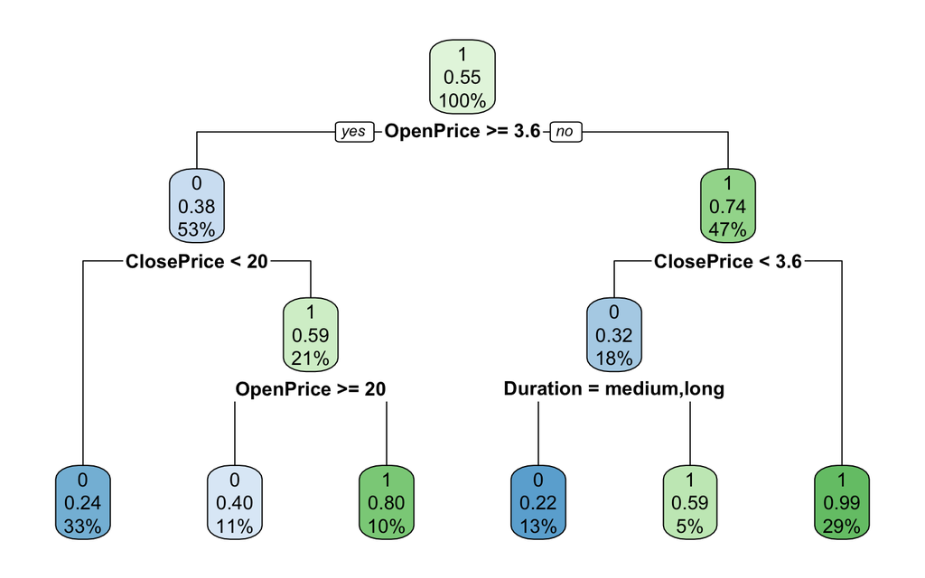

```r
rpart.plot(fit, extra = 106)
```

Rules: 1- If (OpenPrice >= 3.6) AND (ClosePrice < 20) Than (Competitive = No) 2- If (OpenPrice >= 3.6) AND (ClosePrice >= 20) And (OpenPrice >= 20) Than (Competitive = No) 3- If (OpenPrice >= 3.6) AND (ClosePrice >= 20) And (OpenPrice < 20) Than (Competitive = Yes) 4- If (OpenPrice < 3.6) AND (ClosePrice < 3.6) And (Duration = Medium, Long) Than (Competitive = No) 5- If (OpenPrice < 3.6) AND (ClosePrice < 3.6) And (Duration != Medium, Long) Than (Competitive = Yes) 5- If (OpenPrice < 3.6) AND (ClosePrice > 3.6) Than (Competitive = Yes)

If we had to reduce the number of predictors I believe Currency, Category, and EndDay can be removed because they do not have any significant prediction power over this data.

**b.** We cannot use this model to predict the outcome of new auction, because it uses some variables as predictor which are not accessible before the auction. Thus, is it not possible to predict a variable based on the variables that we do not have.

**c.** According to the decision tree, 55 percent of the auctions are competitive. It is interesting that if open price be less than 3.6 and close price more than 3.6, there is a 99 percent chance that the auction was competitive. 53 percent of auctions have open price of more than 3.6.

**d.** In this part we fit another decision tree using the predictors that can be used for predicting a new auction.

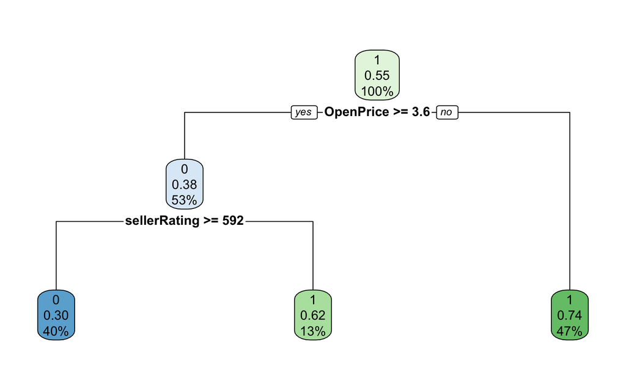

```r
fit <- rpart(Competitive.~ Category + sellerRating + OpenPrice, data = data_train, method = "class", minbucket=50, maxdepth=7)

rpart.plot(fit, extra = 106)
```

Rules: 1- If (OpenPrice >= 3.6) AND (sellerRating >= 592) Than (Competitive = No) 2- If (OpenPrice >= 3.6) AND (sellerRating < 592) Than (Competitive = Yes) 3- If (OpenPrice < 3.6) Than (Competitive = Yes)

**e.** In this section we plot the resulting tree using a scatter plot.

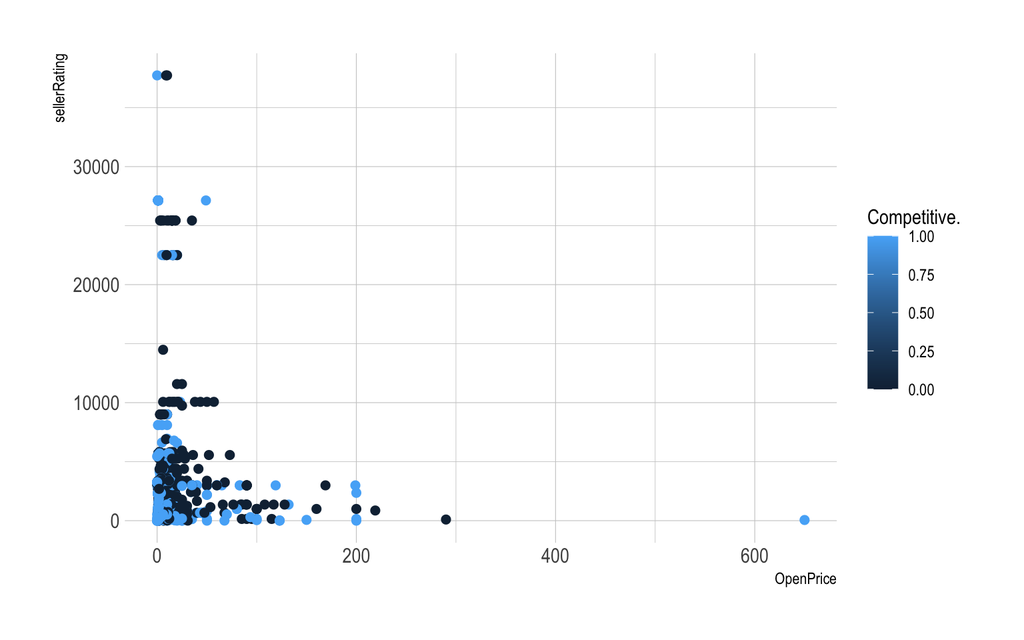

```r
library(ggplot2)
library(hrbrthemes)


ggplot(data_train, aes(x=OpenPrice, y=sellerRating, color=Competitive.)) +
    geom_point(size=2) +
    theme_ipsum()
```

We have to delete the outliers to be able to draw the lines to classify the variable.

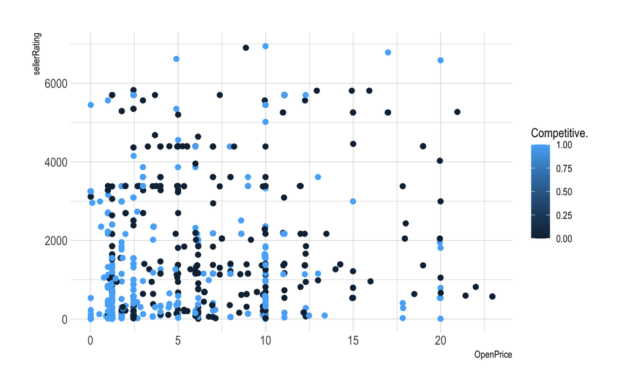

```r
Q1 <- quantile(data_train$OpenPrice, probs=c(.25, .75), na.rm = FALSE)
Q2 <- quantile(data_train$sellerRating, probs=c(.25, .75), na.rm = FALSE)

eliminated_train<- subset(data_train, data_train$OpenPrice > (Q1[1] - 1.5*IQR(data_train$OpenPrice)) & data_train$OpenPrice < (Q1[2]+1.5*IQR(data_train$OpenPrice)) & data_train$sellerRating > (Q2[1] - 1.5*IQR(data_train$sellerRating)) & data_train$sellerRating < (Q2[2]+1.5*IQR(data_train$sellerRating)))

ggplot(eliminated_train, aes(x=OpenPrice, y=sellerRating, color=Competitive.)) +
    geom_point(size=2) +
    theme_ipsum()
```

Now we will add the splitting lines.

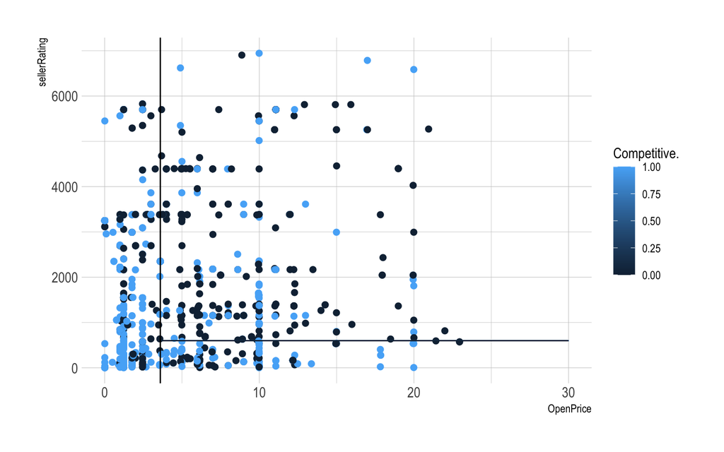

```r
ggplot(eliminated_train, aes(x=OpenPrice, y=sellerRating, color=Competitive.)) +
    geom_point(size=2) +
    theme_ipsum() +
    geom_segment(aes(x = 3.6, y = 598, xend = 30, yend = 598)) +
    geom_vline(xintercept = 3.6)
```

When open price is under 3.6 the auction is usually competitive which I think is reasonable as there are more people who can afford the product and its reasonable to have more than 1 bid. However, when the open price is more than 3.6 and the seller rating is more than 592 the auctions is usually not competitive which I do not find it reasonable. Thus, this needs more information about the data and the auction, because I do not know how the sellers are rated.

**f.** First, we predict the test data using the decision tree.

```r
predict_unseen <-predict(fit, data_test, type = 'class')
#predict_unseen

table_mat <- table(data_test$Competitive., predict_unseen)
table_mat
```

```
##    predict_unseen
##       0   1
##   0 237 131
##   1 104 317
```

```r
head(data_test[which(predict_unseen != data_test$Competitive.), ])
```

```
##               Category currency sellerRating Duration endDay ClosePrice
## 605  Antique/Art/Craft       US         2349   medium    Mon       3.60
## 1242     SportingGoods      EUR         5701     long    Mon      11.68
## 156   Music/Movie/Game      GBP         1029   medium    Thu       1.25
## 236       Collectibles      EUR         1853     long    Tue       1.23
## 716       Toys/Hobbies       US         3385   medium    Sat       5.02
## 1761      Toys/Hobbies       US          534   medium    Sun      29.95
##      OpenPrice Competitive.
## 605       3.60            0
## 1242     11.07            1
## 156       1.25            0
## 236       1.23            0
## 716       3.75            1
## 1761     29.95            0
```

```r
head(data_test)
```

```
##               Category currency sellerRating   Duration endDay ClosePrice
## 605  Antique/Art/Craft       US         2349     medium    Mon       3.60
## 513      SportingGoods       US         2378       <NA>    Fri     860.00
## 853        Photography       US         1004 very short    Fri      26.78
## 1242     SportingGoods      EUR         5701       long    Mon      11.68
## 156   Music/Movie/Game      GBP         1029     medium    Thu       1.25
## 1756        Automotive       US          816      short    Mon      29.00
##      OpenPrice Competitive.
## 605       3.60            0
## 513       0.01            1
## 853       0.99            1
## 1242     11.07            1
## 156       1.25            0
## 1756     29.00            0
```

Then we preform an accuracy test from the confusion matrix.

```r
accuracy_Test <- sum(diag(table_mat)) / sum(table_mat)
print(paste('Accuracy for test', accuracy_Test))
```

```
## [1] "Accuracy for test 0.702154626108999"
```

As can be seen by the confusion matrix accuracy test, the model has an accuracy of about 70% which is not perfect, but it is something to build on.

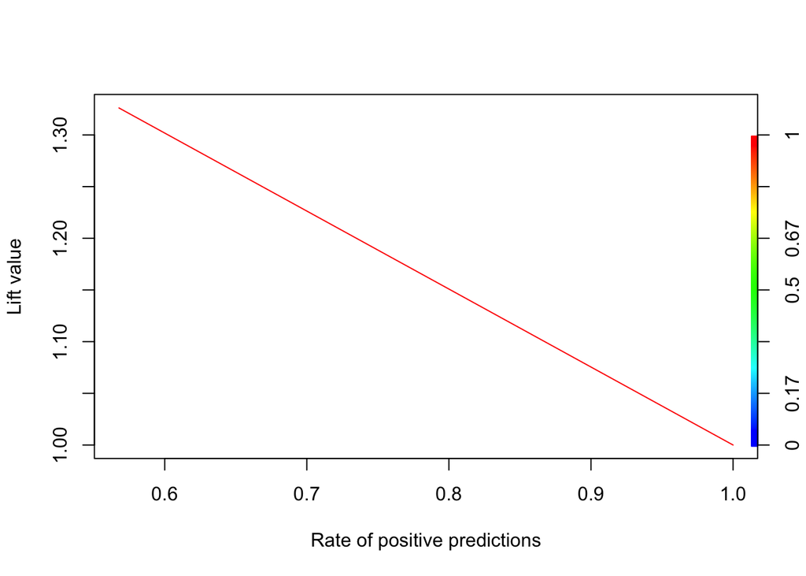

```r
predict_unseen <- as.numeric(as.character(predict_unseen))
library(ROCR)
 predict_vall <- prediction(predict_unseen, data_test$Competitive.)
plot(performance(predict_vall, measure="lift", x.measure="rpp"), colorize=TRUE)
```

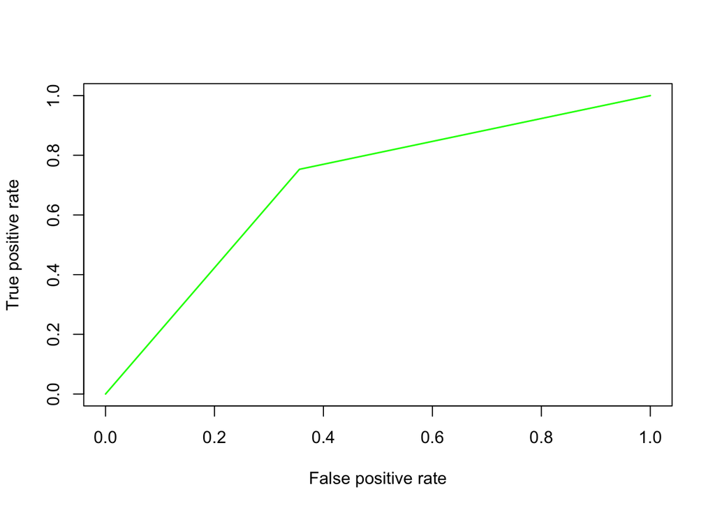

```r
# Calculating True Positive and False Positive Rate
perf_val <- performance(predict_vall, "tpr", "fpr")
#Plot the ROC curve
plot(perf_val, col = "green", lwd = 1.5)
```

```r
ks1.tree <- max(attr(perf_val, "y.values")[[1]] - (attr(perf_val, "x.values")[[1]]))
ks1.tree
```

```
## [1] 0.3969909
```

Overall, using the lift chart and the confusion matrix indicated that the model have a good accuracy but by doing extra work we should be able to increase the accuracy.